part 3 - reporting

```r
library('trainr2')

## remove these patients from analyses
rm_pt <- c(2, 5, 15)
rm_pt <- NULL

## write tables to file
write_table <- FALSE
```

###### All analyses were performed using R version 3.6.0 (2019-04-26) and packages `survival` v2.44.1.1 for time-to-event analyses; and `knitr` v1.23 for reproducible research.

## Design

### Study objectives

The primary outcome was overall response rate (ORR).

The secondary outcomes were:

- rate of PR, CR or better
- progression-free survival
- overall survival
- safety

### Statistical methods

All subjects will be evaluable for toxicity from the time of their first treatment with study drug.

Overall Survival (OS) will be measured from date of protocol therapy initiation until date of death and characterized using the Kaplan-Meier method.

Progression-free Survival (PFS) will be measured from date of protocol therapy initiation until date of documentation of progressive disease or death from any cause and calculated using the Kaplan-Meier method.

Time-to-event endpoints are estimated using the method of Kaplan and Meier with 95% confidence intervals calculated using Greenwood’s method of variance estimation. Median follow-up is calculated using the reverse Kaplan-Meier method.

Responses to study treatment were reported as proportions with 95% exact binomial confidence intervals. Continuous measures summarized as median and range, and categorical variables are summarized as proportions.

Nominal variables were tested for association with continuous and other categorical variables using Wilcoxon rank-sum (or Kruskal-Wallis for three or more groups) or Fisher’s exact tests, respectively. Ordinal variables were tested using trend tests (Cuzick, KW, JT) where appropriate.

Statistical analyses were performed using R version 3.6.0 (2019-04-26).

## Administrative Information

From April 2012 to May 2013, 50 patients were enrolled on study at BWH (n = 19, 38%), DFCI (n = 12, 24%), and MGH (n = 19, 38%). As per inclusion criteria, all patients were newly diagnosed diffuse large B-cell lymphoma (DLBCL). Per protocol patients were analyzed by subtype, activated B cell-like (ABC) and germinal center B cell–like (GCB).

50 patients received at least one dose of study treatment and were included in toxicity and response analyses.

## Patient Characteristics

Patient characteristics are presented in Table 1. 29 (58% of) patients enrolled were male. The median age at diagnosis was 66 (range: 36 - 89). 40 (80% of) patients had International Prognostic Index (IPI) of two or more.

| Table 1: Patient characteristics. | Table 1: Patient characteristics. Total n = 50 (%) | Table 1: Patient characteristics. | Table 1: Patient characteristics. Subtype ABC n = 28 (56) | Table 1: Patient characteristics. Subtype GCB n = 22 (44) | Table 1: Patient characteristics. | Table 1: Patient characteristics. *p-value* |
| --- | --- | --- | --- | --- | --- | --- |
| Age at diagnosis |  |  |  |  |  |  |
| Median (range) | 66 (36 - 89) |  | 63 (38 - 89) | 70 (36 - 88) |  | *0.76*† |
| 36 - 50 | 14 (28) |  | 8 (29) | 6 (27) |  | *0.62*<sup>§</sup> |
| 51 - 70 | 16 (32) |  | 10 (36) | 6 (27) |  |  |
| 71 - 89 | 20 (40) |  | 10 (36) | 10 (45) |  |  |
| Site |  |  |  |  |  |  |
| BWH | 19 (38) |  | 11 (39) | 8 (36) |  | *0.88*‡ |
| DFCI | 12 (24) |  | 6 (21) | 6 (27) |  |  |
| MGH | 19 (38) |  | 11 (39) | 8 (36) |  |  |
| Sex |  |  |  |  |  |  |
| Female | 21 (42) |  | 15 (54) | 6 (27) |  | *0.086*‡ |
| Male | 29 (58) |  | 13 (46) | 16 (73) |  |  |
| Race |  |  |  |  |  |  |
| Asian | 6 (12) |  | 4 (14) | 2 (9) |  | *0.62*‡ |
| Black | 6 (12) |  | 2 (7) | 4 (18) |  |  |
| White | 38 (76) |  | 22 (79) | 16 (73) |  |  |
| Ethnicity |  |  |  |  |  |  |
| Hispanic | 11 (22) |  | 4 (14) | 7 (32) |  | *0.18*‡ |
| Non-Hispanic | 39 (78) |  | 24 (86) | 15 (68) |  |  |
| IPI Factors |  |  |  |  |  |  |
| Age |  |  |  |  |  |  |
| > 60 | 30 (60) |  | 15 (54) | 15 (68) |  | *0.39*‡ |
| ≤ 60 | 20 (40) |  | 13 (46) | 7 (32) |  |  |
| ECOG PS |  |  |  |  |  |  |
| > 1 | 32 (64) |  | 18 (64) | 14 (64) |  | *> 0.99*‡ |
| ≤ 1 | 18 (36) |  | 10 (36) | 8 (36) |  |  |
| Disease stage |  |  |  |  |  |  |
| Stage I/II | 24 (48) |  | 11 (39) | 13 (59) |  | *0.25*‡ |
| Stage III/IV | 26 (52) |  | 17 (61) | 9 (41) |  |  |
| LDH |  |  |  |  |  |  |
| Elevated | 25 (50) |  | 11 (39) | 14 (64) |  | *0.15*‡ |
| Normal | 25 (50) |  | 17 (61) | 8 (36) |  |  |
| ENS |  |  |  |  |  |  |
| > 1 | 28 (56) |  | 16 (57) | 12 (55) |  | *> 0.99*‡ |
| ≤ 1 | 22 (44) |  | 12 (43) | 10 (45) |  |  |
| IPI Risk Score |  |  |  |  |  |  |
| IPI |  |  |  |  |  |  |
| Low (0-1) | 10 (20) |  | 6 (21) | 4 (18) |  | *0.22*<sup>§</sup> |
| Low-Int (2) | 17 (34) |  | 11 (39) | 6 (27) |  |  |
| High-Int (3) | 20 (40) |  | 11 (39) | 9 (41) |  |  |
| High (4-5) | 3 (6) |  | - | 3 (14) |  |  |

†Wilcoxon rank-sum test, <sup>§</sup>Kruskal-Wallis trend test, ‡Fisher’s exact test Abbreviations: IPI, international prognostic score; ECOG PS, Eastern Cooperative Oncology Group performance score.

## Baseline labs

Lab results at study entry are presented in Table 2. The median sum of largest tumor diameters at baseline was 70.25 for all patients and 71.7 and 68.3 for ABC and GCB suptype patients, respectively (p = 0.72).

| Table 2: Baseline labs with p-values corrected for multiple testing. | Table 2: Baseline labs with p-values corrected for multiple testing. Total n = 50 (%) | Table 2: Baseline labs with p-values corrected for multiple testing. | Table 2: Baseline labs with p-values corrected for multiple testing. Subtype ABC n = 28 (56) | Table 2: Baseline labs with p-values corrected for multiple testing. Subtype GCB n = 22 (44) | Table 2: Baseline labs with p-values corrected for multiple testing. | Table 2: Baseline labs with p-values corrected for multiple testing. *p-value* | Table 2: Baseline labs with p-values corrected for multiple testing. *fdr p-value* |
| --- | --- | --- | --- | --- | --- | --- | --- |
| ltd |  |  |  |  |  |  |  |
| Median (range) | 70.2 (50.5 - 99.0) |  | 71.7 (51.2 - 98.4) | 68.3 (50.5 - 99.0) |  | *0.72*† | 0.98 |
| wbc |  |  |  |  |  |  |  |
| Median (range) | 13.4 (5.2 - 19.9) |  | 13.1 (5.2 - 19.9) | 13.6 (5.5 - 19.6) |  | *0.43*† | 0.76 |
| hgb |  |  |  |  |  |  |  |
| Median (range) | 11.7 (5.1 - 19.9) |  | 13.2 (5.1 - 19.8) | 10.9 (5.5 - 19.9) |  | *0.98*† | 0.98 |
| platelets |  |  |  |  |  |  |  |
| Median (range) | 148 (132 - 172) |  | 150 (132 - 171) | 143 (132 - 172) |  | *0.13*† | 0.76 |
| neutrophils |  |  |  |  |  |  |  |
| Median (range) | 50 (35 - 66) |  | 54 (35 - 66) | 49 (42 - 65) |  | *0.38*† | 0.76 |
| lymphocytes |  |  |  |  |  |  |  |
| Median (range) | 28 (17 - 42) |  | 28 (17 - 37) | 28 (20 - 42) |  | *0.30*† | 0.76 |
| monocytes |  |  |  |  |  |  |  |
| Median (range) | 10 (5 - 21) |  | 10 (5 - 21) | 9 (5 - 16) |  | *0.84*† | 0.98 |

†Wilcoxon rank-sum test

## Treatment toxicities

Toxicities attributed to study treatment (possible, probable, definite) are presented in Tables 3A and 3B. All patients received at least on dose of study treatment and were included in toxicity summary. The most common toxicities on study were Bone marrow hypocellular (n = 30, 60%), Hemolytic uremic syndrome (n = 29, 58%), Atrial fibrillation (n = 28, 56%), Anemia (n = 27, 54%), and Asystole (n = 27, 54%).

The highest grades experienced among all patients regardless of toxicity were 1 (n = 1/50, 2%), 2 (n = 4/50, 8%), 3 (n = 20/50, 40%), and 4 (n = 25/50, 50%).

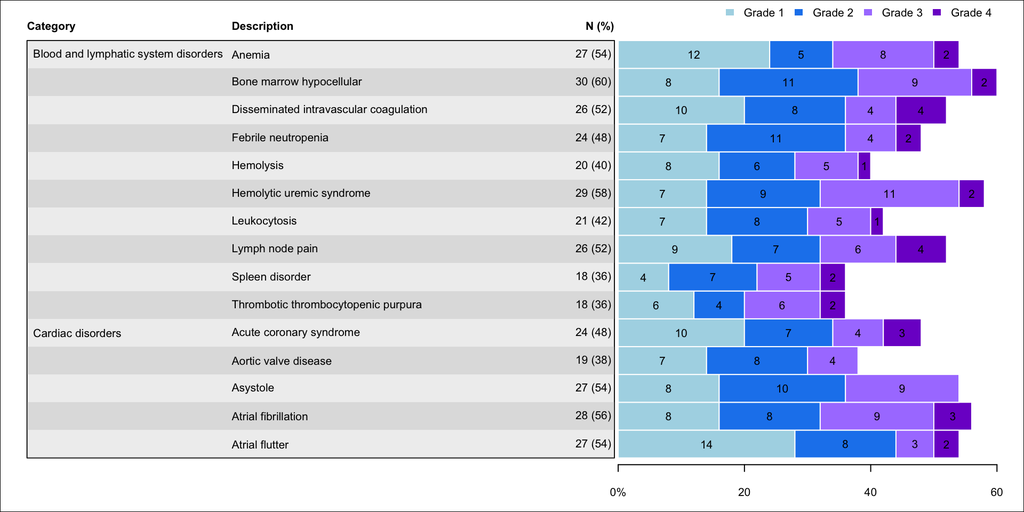

| Table 3A: Highest grade toxicity experienced for n=50 patients. Category | Table 3A: Highest grade toxicity experienced for n=50 patients. Description | Table 3A: Highest grade toxicity experienced for n=50 patients. Total N=50 | Table 3A: Highest grade toxicity experienced for n=50 patients. | Table 3A: Highest grade toxicity experienced for n=50 patients. Highest grade 1 | Table 3A: Highest grade toxicity experienced for n=50 patients. Highest grade 2 | Table 3A: Highest grade toxicity experienced for n=50 patients. Highest grade 3 | Table 3A: Highest grade toxicity experienced for n=50 patients. Highest grade 4 |
| --- | --- | --- | --- | --- | --- | --- | --- |
| Blood and lymphatic system disorders | Anemia | 27 (54) |  | 12 (24) | 5 (10) | 8 (16) | 2 (4) |
|  | Bone marrow hypocellular | 30 (60) |  | 8 (16) | 11 (22) | 9 (18) | 2 (4) |
|  | Disseminated intravascular coagulation | 26 (52) |  | 10 (20) | 8 (16) | 4 (8) | 4 (8) |
|  | Febrile neutropenia | 24 (48) |  | 7 (14) | 11 (22) | 4 (8) | 2 (4) |
|  | Hemolysis | 20 (40) |  | 8 (16) | 6 (12) | 5 (10) | 1 (2) |
|  | Hemolytic uremic syndrome | 29 (58) |  | 7 (14) | 9 (18) | 11 (22) | 2 (4) |
|  | Leukocytosis | 21 (42) |  | 7 (14) | 8 (16) | 5 (10) | 1 (2) |
|  | Lymph node pain | 26 (52) |  | 9 (18) | 7 (14) | 6 (12) | 4 (8) |
|  | Spleen disorder | 18 (36) |  | 4 (8) | 7 (14) | 5 (10) | 2 (4) |
|  | Thrombotic thrombocytopenic purpura | 18 (36) |  | 6 (12) | 4 (8) | 6 (12) | 2 (4) |
| Cardiac disorders | Acute coronary syndrome | 24 (48) |  | 10 (20) | 7 (14) | 4 (8) | 3 (6) |
|  | Aortic valve disease | 19 (38) |  | 7 (14) | 8 (16) | 4 (8) | - |
|  | Asystole | 27 (54) |  | 8 (16) | 10 (20) | 9 (18) | - |
|  | Atrial fibrillation | 28 (56) |  | 8 (16) | 8 (16) | 9 (18) | 3 (6) |
|  | Atrial flutter | 27 (54) |  | 14 (28) | 8 (16) | 3 (6) | 2 (4) |

| Table 3B: Highest grade toxicity experienced for n=50 patients, by Subtype | Table 3B: Highest grade toxicity experienced for n=50 patients, by Subtype Total n = 50 (%) | Table 3B: Highest grade toxicity experienced for n=50 patients, by Subtype | Table 3B: Highest grade toxicity experienced for n=50 patients, by Subtype ABC Total n = 28 (56) | Table 3B: Highest grade toxicity experienced for n=50 patients, by Subtype ABC 1 | Table 3B: Highest grade toxicity experienced for n=50 patients, by Subtype ABC 2 | Table 3B: Highest grade toxicity experienced for n=50 patients, by Subtype ABC 3 | Table 3B: Highest grade toxicity experienced for n=50 patients, by Subtype ABC 4 | Table 3B: Highest grade toxicity experienced for n=50 patients, by Subtype | Table 3B: Highest grade toxicity experienced for n=50 patients, by Subtype GCB Total n = 22 (44) | Table 3B: Highest grade toxicity experienced for n=50 patients, by Subtype GCB 1 | Table 3B: Highest grade toxicity experienced for n=50 patients, by Subtype GCB 2 | Table 3B: Highest grade toxicity experienced for n=50 patients, by Subtype GCB 3 | Table 3B: Highest grade toxicity experienced for n=50 patients, by Subtype GCB 4 |
| --- | --- | --- | --- | --- | --- | --- | --- | --- | --- | --- | --- | --- | --- |
| Bone marrow hypocellular | 30 (60) |  | 16 (57) | 4 (14) | 6 (21) | 6 (21) | - |  | 14 (64) | 4 (18) | 5 (23) | 3 (14) | 2 (9) |
| Hemolytic uremic syndrome | 29 (58) |  | 16 (57) | 4 (14) | 3 (11) | 8 (29) | 1 (4) |  | 13 (59) | 3 (14) | 6 (27) | 3 (14) | 1 (5) |
| Atrial fibrillation | 28 (56) |  | 16 (57) | 6 (21) | 5 (18) | 4 (14) | 1 (4) |  | 12 (55) | 2 (9) | 3 (14) | 5 (23) | 2 (9) |
| Anemia | 27 (54) |  | 14 (50) | 8 (29) | 3 (11) | 3 (11) | - |  | 13 (59) | 4 (18) | 2 (9) | 5 (23) | 2 (9) |
| Asystole | 27 (54) |  | 15 (54) | 2 (7) | 7 (25) | 6 (21) | - |  | 12 (55) | 6 (27) | 3 (14) | 3 (14) | - |
| Atrial flutter | 27 (54) |  | 14 (50) | 7 (25) | 4 (14) | 2 (7) | 1 (4) |  | 13 (59) | 7 (32) | 4 (18) | 1 (5) | 1 (5) |
| Disseminated intravascular coagulation | 26 (52) |  | 13 (46) | 6 (21) | 4 (14) | 2 (7) | 1 (4) |  | 13 (59) | 4 (18) | 4 (18) | 2 (9) | 3 (14) |
| Lymph node pain | 26 (52) |  | 13 (46) | 5 (18) | 3 (11) | 4 (14) | 1 (4) |  | 13 (59) | 4 (18) | 4 (18) | 2 (9) | 3 (14) |
| Acute coronary syndrome | 24 (48) |  | 13 (46) | 6 (21) | 5 (18) | - | 2 (7) |  | 11 (50) | 4 (18) | 2 (9) | 4 (18) | 1 (5) |
| Febrile neutropenia | 24 (48) |  | 13 (46) | 3 (11) | 7 (25) | 3 (11) | - |  | 11 (50) | 4 (18) | 4 (18) | 1 (5) | 2 (9) |
| Leukocytosis | 21 (42) |  | 14 (50) | 6 (21) | 5 (18) | 3 (11) | - |  | 7 (32) | 1 (5) | 3 (14) | 2 (9) | 1 (5) |
| Hemolysis | 20 (40) |  | 9 (32) | 5 (18) | 2 (7) | 1 (4) | 1 (4) |  | 11 (50) | 3 (14) | 4 (18) | 4 (18) | - |
| Aortic valve disease | 19 (38) |  | 10 (36) | 3 (11) | 5 (18) | 2 (7) | - |  | 9 (41) | 4 (18) | 3 (14) | 2 (9) | - |
| Spleen disorder | 18 (36) |  | 10 (36) | - | 4 (14) | 4 (14) | 2 (7) |  | 8 (36) | 4 (18) | 3 (14) | 1 (5) | - |
| Thrombotic thrombocytopenic purpura | 18 (36) |  | 12 (43) | 4 (14) | 3 (11) | 3 (11) | 2 (7) |  | 6 (27) | 2 (9) | 1 (5) | 3 (14) | - |

## Outcome summary

### Response to treatment

The primary outcome was overall response rate (MR, PR, CR) at end of treatment. All patients received at least one dose of study treatment and were included in response assessment, and all patients were evaluated for EOT response.

The overall response rate of MR or better was 32/50, 64% (95% CI: 49 - 77%). 24 (48% of) patients experienced a PR or better at EOT (95% CI: 34 - 63%). 12 (24% of) patients experienced a CR or better (95% CI: 13 - 38%).

| Table 4: Overall response rate. | Table 4: Overall response rate. Response CR | Table 4: Overall response rate. Response PR | Table 4: Overall response rate. Response MR | Table 4: Overall response rate. Response SD | Table 4: Overall response rate. Response PD | Table 4: Overall response rate. | Table 4: Overall response rate. Outcome MR or better | Table 4: Overall response rate. Outcome PR or better |
| --- | --- | --- | --- | --- | --- | --- | --- | --- |
| Subtype |  |  |  |  |  |  |  |  |
| ABC | 4/28, 14% (4 - 33%) | 8/28, 29% (13 - 49%) | 5/28, 18% (6 - 37%) | 6/28, 21% (8 - 41%) | 5/28, 18% (6 - 37%) |  | 17/28, 61% (41 - 78%) | 12/28, 43% (24 - 63%) |
| GCB | 8/22, 36% (17 - 59%) | 4/22, 18% (5 - 40%) | 3/22, 14% (3 - 35%) | 6/22, 27% (11 - 50%) | 1/22, 5% (0 - 23%) |  | 15/22, 68% (45 - 86%) | 12/22, 55% (32 - 76%) |
| Overall |  |  |  |  |  |  |  |  |
|  | 12/50, 24% (13 - 38%) | 12/50, 24% (13 - 38%) | 8/50, 16% (7 - 29%) | 12/50, 24% (13 - 38%) | 6/50, 12% (5 - 24%) |  | 32/50, 64% (49 - 77%) | 24/50, 48% (34 - 63%) |

### Time-to-event

Median follow-up was 20 months. Patients were followed for progression-free and overall survival; results are shown in Table 5.

The median OS and PFS were 24 (95% CI: 24 - NR) and 24 (95% CI: 21 - NR), respectively. 12- and 24-month PFS were 89 and 62 percent.

Median PFS by subtype was not reached and 24 months, p = 0.11.

| Table 5: Progression-free and overall survival. Time | Table 5: Progression-free and overall survival. No. at risk | Table 5: Progression-free and overall survival. No. event | Table 5: Progression-free and overall survival. Std.Error | Table 5: Progression-free and overall survival. Surv (95% CI) |
| --- | --- | --- | --- | --- |
| Progression-free survival |  |  |  |  |
| 0 | 50 | 0 | 0.000 | 1.000 (1.000, 1.000) |
| 6 | 47 | 3 | 0.034 | 0.940 (0.876, 1.000) |
| 12 | 31 | 2 | 0.047 | 0.890 (0.802, 0.987) |
| 18 | 28 | 2 | 0.060 | 0.831 (0.721, 0.956) |
| 24 | 5 | 5 | 0.095 | 0.616 (0.456, 0.834) |
| Overall survival |  |  |  |  |
| 0 | 50 | 0 | 0.000 | 1.000 (1.000, 1.000) |
| 6 | 50 | 0 | 0.000 | 1.000 (1.000, 1.000) |
| 12 | 31 | 2 | 0.037 | 0.947 (0.877, 1.000) |
| 18 | 29 | 1 | 0.047 | 0.915 (0.827, 1.000) |
| 24 | 5 | 3 | 0.080 | 0.788 (0.647, 0.961) |

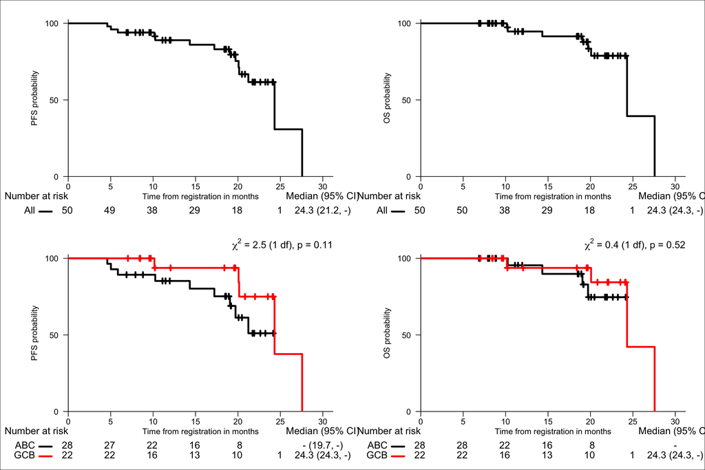

## References

R Core Team (2019). *R: A Language and Environment for Statistical Computing*. R Foundation for Statistical Computing, Vienna, Austria. https://www.R-project.org/.

Therneau T (2015). *A Package for Survival Analysis in S*. version 2.38, https://CRAN.R-project.org/package=survival.

Terry M. Therneau, Patricia M. Grambsch (2000). *Modeling Survival Data: Extending the Cox Model*. Springer, New York. ISBN 0-387-98784-3.

## Appendix

### Response data

| Table A1: All response data. id | Table A1: All response data. resp | Table A1: All response data. d_resp | Table A1: All response data. m_resp | Table A1: All response data. y_resp |
| --- | --- | --- | --- | --- |
| 1 | PD | 9 | 10 | 2013 |
| 2 | PR | 16 | 10 | 2013 |
| 3 | PR | 21 | 11 | 2013 |
| 4 | PR | 5 | 12 | 2013 |
| 5 | PR | 20 | 8 | 2013 |
| 6 | PD | 25 | 9 | 2013 |
| 7 | SD | 11 | 8 | 2013 |
| 8 | SD | 1 | 9 | 2013 |
| 9 | MR | 15 | 12 | 2013 |
| 10 | PR | 4 | 11 | 2013 |
| … | … | … | … | … |

### Toxicity data

| Table A2: All toxicity data. | Table A2: All toxicity data. id | Table A2: All toxicity data. tox_code | Table A2: All toxicity data. tox_grade | Table A2: All toxicity data. tox_desc | Table A2: All toxicity data. tox_cat |
| --- | --- | --- | --- | --- | --- |
| 1 | 1 | BL101 | 1 | Anemia | Blood and lymphatic system disorders |
| 2 | 1 | BL105 | 1 | Hemolysis | Blood and lymphatic system disorders |
| 3 | 1 | BL106 | 2 | Hemolytic uremic syndrome | Blood and lymphatic system disorders |
| 4 | 1 | BL106 | 2 | Hemolytic uremic syndrome | Blood and lymphatic system disorders |
| 5 | 1 | BL106 | 3 | Hemolytic uremic syndrome | Blood and lymphatic system disorders |
| 6 | 1 | BL108 | 4 | Lymph node pain | Blood and lymphatic system disorders |
| 7 | 1 | BL109 | 3 | Spleen disorder | Blood and lymphatic system disorders |
| 8 | 1 | BL109 | 3 | Spleen disorder | Blood and lymphatic system disorders |
| 9 | 1 | CA101 | 1 | Acute coronary syndrome | Cardiac disorders |
| 10 | 1 | CA101 | 1 | Acute coronary syndrome | Cardiac disorders |
|  | … | … | … | … | … |